# Major League Baseball Salary Prediction

```
Required packages
```

```r
library(tidyverse)
library(caret)
library(glmnet)
library(ISLR)
```

# Major League Baseball

The dataset we are using is one provided by the ISLR package. It contains Major League Baseball Data from the 1986 and 1987 seasons with 322 observations with 20 variables. It has some missing cases that isn’t the focus of this module and can be removed with the following code.

```r
data(Hitters, package = "ISLR")
Hitters <- na.omit(Hitters)
```

## Stepwise selection

Implement a **backward** stepwise selection procedure to remove five features. The response feature here is `Salary` which is numeric, so this is a regression and not a classification problem. Use the Root MSE as the performance metric for each selection step. Similar to the lab you may use `caret` to create a training and test split but otherwise implement the solution without using other packages (using `tidyverse` syntax is fine).

```r
## Candidate features
features <- colnames(Hitters)
features <- features[features != "Salary"]
### Assess model on all candidates
set.seed(5003)
train_indices <- createDataPartition(Hitters$Salary, p = 0.6)[[1]]
train_data <- Hitters[train_indices, ]
test_data <- Hitters[-train_indices, ]

# Full model
model_full <- lm(Salary ~ ., data = train_data)

# Perform backward stepwise regression (remove features one by one)
model_step <- step(model_full, direction = "backward", trace = FALSE, k = log(nrow(train_data)))

# Summary of selected model
summary(model_step)
```

```
Call:
lm(formula = Salary ~ AtBat + Hits + Walks + CRuns + CWalks +
    PutOuts, data = train_data)

Residuals:
    Min      1Q  Median      3Q     Max
-883.75 -179.24  -31.03   94.86 2038.79

Coefficients:
            Estimate Std. Error t value Pr(>|t|)
(Intercept) 106.4329    85.1339   1.250 0.213129
AtBat        -2.5198     0.7801  -3.230 0.001513 **
Hits          8.1589     2.4441   3.338 0.001058 **
Walks         6.8351     2.0277   3.371 0.000947 ***
CRuns         1.3000     0.2554   5.090 1.03e-06 ***
CWalks       -1.0901     0.3493  -3.120 0.002157 **
PutOuts       0.2680     0.1068   2.510 0.013106 *
---
Signif. codes:  0 '***' 0.001 '**' 0.01 '*' 0.05 '.' 0.1 ' ' 1

Residual standard error: 335.2 on 154 degrees of freedom
Multiple R-squared:  0.4513,    Adjusted R-squared:  0.4299
F-statistic: 21.11 on 6 and 154 DF,  p-value: < 2.2e-16
```

```r
# Predict on test data
predictions <- predict(model_step, newdata = test_data)

# Calculate RMSE for stepwise model
rmse_step <- sqrt(mean((predictions - test_data$Salary)^2))
rmse_step
```

```
[1] 318.2794
```

## Lasso regression

### Split data and fit

Split the dataset into 60% train and 40% test. Perform a lasso regression using the `glmnet` package. Now I will perform Lasso Regression using the glmnet package, this technique applies L1 regularisation to shrink some coefficients exactly to zero, so performing variable selection.

```r
# Create design matrices for glmnet
# 1. Create the design matrices (you already have this)
x_train <- model.matrix(Salary ~ ., train_data)[, -1]
y_train <- train_data$Salary

x_test <- model.matrix(Salary ~ ., test_data)[, -1]
y_test <- test_data$Salary

# 2. Fit Lasso model using cross-validation
library(glmnet)  # Ensure glmnet is loaded
set.seed(5003)
lasso_model <- cv.glmnet(x_train, y_train, alpha = 1)  # This is what defines 'lasso_model'

# 3. Best lambda
best_lambda <- lasso_model$lambda.min

# 4. Predict
lasso_preds <- predict(lasso_model, s = best_lambda, newx = x_test)

# 5. Evaluate RMSE
rmse_lasso <- sqrt(mean((lasso_preds - y_test)^2))
rmse_lasso
```

```
[1] 302.7225
```

### Inspect coefficients as function of $\lambda$

Plot the lasso regression coefficients as a function of $\lambda$. Use cross-validation to find the best $\lambda$ value (You can use the inbuilt CV function in glmnet). **Hint** The `cv.glmnet` function will return the best $\lambda$ value as `lambda.min`.

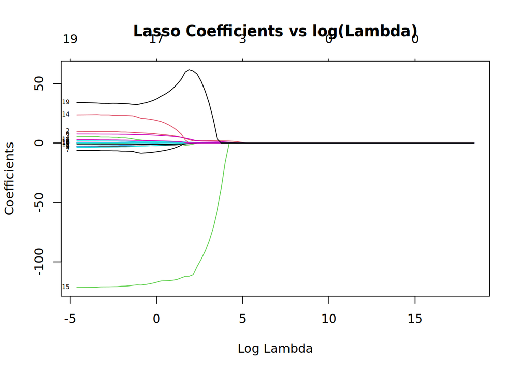

```r
# Set up grid of lambda values
grid <- 10^seq(8, -2, length = 100)

# Fit the lasso model over the lambda grid (no CV yet, just to see paths)
lasso_full <- glmnet(x_train, y_train, alpha = 1, lambda = grid)

# Plot coefficient shrinkage paths against log(lambda)
plot(lasso_full, xvar = "lambda", label = TRUE)
title("Lasso Coefficients vs log(Lambda)")
```

Cross-Validation to Find Optimal $\lambda$

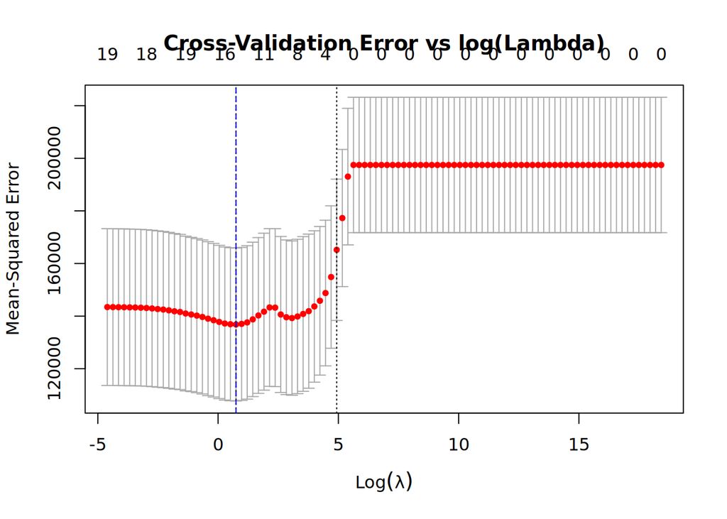

```r
# Perform cross-validation to select best lambda
set.seed(5003)
lasso_model <- cv.glmnet(x_train, y_train, alpha = 1, lambda = grid)

# Plot mean cross-validated error curve
plot(lasso_model)
abline(v = log(lasso_model$lambda.min), col = "blue", lty = 2)
title("Cross-Validation Error vs log(Lambda)")
```

Print Best Lambda Value

```r
# Best lambda value from CV
lasso_model$lambda.min
```

```
[1] 2.104904
```

### Check if model is sparse

Inspect the coefficients in the best model above and check if there there are any coefficients that have been shrunk to zero. **Hint** The `cv.glmnet` will also return the model fits for each $\lambda$ value. You can extract the coefficients for each $\lambda$ value using `cv.out$glmnet.fit$beta`.

```r
# Extract the coefficients at the best lambda
lasso_coefs <- coef(lasso_model, s = lasso_model$lambda.min)

# Show non-zero coefficients
lasso_coefs[lasso_coefs != 0]
```

```
 [1]  132.64163949   -1.79764897    6.58409698   -1.49375676    5.83805947
 [6]   -5.47088015    1.05937173    0.98722643    0.13484474   -0.95719987
[11]   15.16747115 -115.82567958    0.22227780    0.04790916    1.50576514
[16]   43.31288063
```

```r
# Count how many were shrunk to zero
num_zero <- sum(lasso_coefs == 0)
cat("Number of coefficients shrunk to zero:", num_zero, "\n")
```

```
Number of coefficients shrunk to zero: 4
```

#### Sparsity Detected

- Lasso has set some coefficients to exactly zero, meaning:
- Those features are excluded from the final model.
- This is a key advantage of Lasso over ordinary least squares — it performs automatic variable selection.
- Model Interpretation
- The variables with non-zero coefficients are the important predictors of Salary. These are the only ones Lasso chose to keep at the best λ.
- Number of Variables Selected
- Since we see fewer than 20 coefficients, it means Lasso shrunk several features to zero. I can count how many:

```r
sum(lasso_coefs != 0)  # total number of non-zero coefficients (includes intercept)
```

```
[1] 16
```

Conclusion: The Lasso regression model resulted in a sparse solution, shrinking several coefficients to zero. This suggests that only a subset of the features are strongly predictive of salary. Such sparsity helps simplify the model and improve interpretability, particularly in the presence of multicollinearity or irrelevant variables.

### Assess on the test set

Using the optimal trained model predict the salary of the test dataset and calculate the mean squared error.

```r
# Predict on test set using the best lambda
lasso_preds <- predict(lasso_model, s = lasso_model$lambda.min, newx = x_test)

# Calculate RMSE
rmse_lasso <- sqrt(mean((lasso_preds - y_test)^2))
rmse_lasso
```

```
[1] 302.8004
```

The Lasso regression model achieved a test set RMSE of 302.8, indicating that the predicted salaries deviate from the actual values by approximately $302,800 on average. This result reflects the model’s generalization performance and can be used to compare against other modeling approaches such as linear regression or stepwise selection.